# | Linear Regression |

In this notebook, we will implement Linear Regression from scratch, laying the foundation for a comprehensive Regression Walkthrough series.

## California Housing Dataset

This dataset contains information collected from the 1990 California census. It is commonly used for regression tasks, where the goal is to predict the **median house value** in a given district based on various demographic and geographic features.

### ➢ Features:

- **MedInc**: Median income in the block group (in tens of thousands of dollars).
- **HouseAge**: Median age of houses in the block group.
- **AveRooms**: Average number of rooms per household.
- **AveBedrms**: Average number of bedrooms per household.
- **Population**: Total population in the block group.
- **AveOccup**: Average number of people per household.
- **Latitude**: Geographical latitude of the block group.
- **Longitude**: Geographical longitude of the block group.

### ★ Target Variable:

- **MedianHouseValue**: Median house value for California districts, expressed in **hundreds of thousands of dollars** ($100,000).

## Let's begin

```python
# Importing necessary packages
import pandas as pd
import numpy as np
import matplotlib.pyplot as plt
import seaborn as sns
from sklearn.datasets import fetch_california_housing # California housing dataset
```

```python
fetch_california_housing().DESCR
```

```
'.. _california_housing_dataset:\n\nCalifornia Housing dataset\n--------------------------\n\n**Data Set Characteristics:**\n\n:Number of Instances: 20640\n\n:Number of Attributes: 8 numeric, predictive attributes and the target\n\n:Attribute Information:\n    - MedInc        median income in block …
```

```python
# Load the dataset and create DataFrame

housing = fetch_california_housing()

X, y = housing.data, housing.target
X_df = pd.DataFrame(X, columns=housing.feature_names)
y_df = pd.DataFrame(y, columns=housing.target_names)
df = X_df.join(y_df)

print(f"There are {len(X_df.columns)} features and one target variable, for a total of {len(df.columns)} variables.\n")

df.head()
```

```
There are 8 features and one target variable, for a total of 9 variables.
```

|  | MedInc | HouseAge | AveRooms | AveBedrms | Population | AveOccup | Latitude | Longitude | MedHouseVal |
| --- | --- | --- | --- | --- | --- | --- | --- | --- | --- |
| 0 | 8.3252 | 41.0 | 6.984127 | 1.023810 | 322.0 | 2.555556 | 37.88 | -122.23 | 4.526 |
| 1 | 8.3014 | 21.0 | 6.238137 | 0.971880 | 2401.0 | 2.109842 | 37.86 | -122.22 | 3.585 |
| 2 | 7.2574 | 52.0 | 8.288136 | 1.073446 | 496.0 | 2.802260 | 37.85 | -122.24 | 3.521 |
| 3 | 5.6431 | 52.0 | 5.817352 | 1.073059 | 558.0 | 2.547945 | 37.85 | -122.25 | 3.413 |
| 4 | 3.8462 | 52.0 | 6.281853 | 1.081081 | 565.0 | 2.181467 | 37.85 | -122.25 | 3.422 |

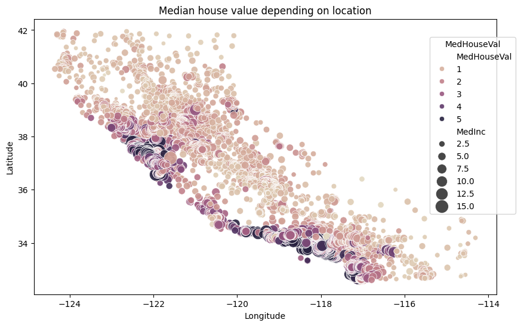

```python
# Visually inspect data through coordinates
## This step is necessary for more advanced techniques -- not in this guide though

plt.figure(figsize = (10, 6))
sns.scatterplot(
    data=df,
    x="Longitude",
    y="Latitude",
    size="MedInc",
    sizes=(20, 250),
    hue="MedHouseVal",
    palette="ch:s=-.2,r=.6",
    alpha=0.9,
)
plt.legend(title="MedHouseVal", bbox_to_anchor=(1.05, 0.95), loc="upper right")
_ = plt.title("Median house value depending on location")
```

## Preprocessing...

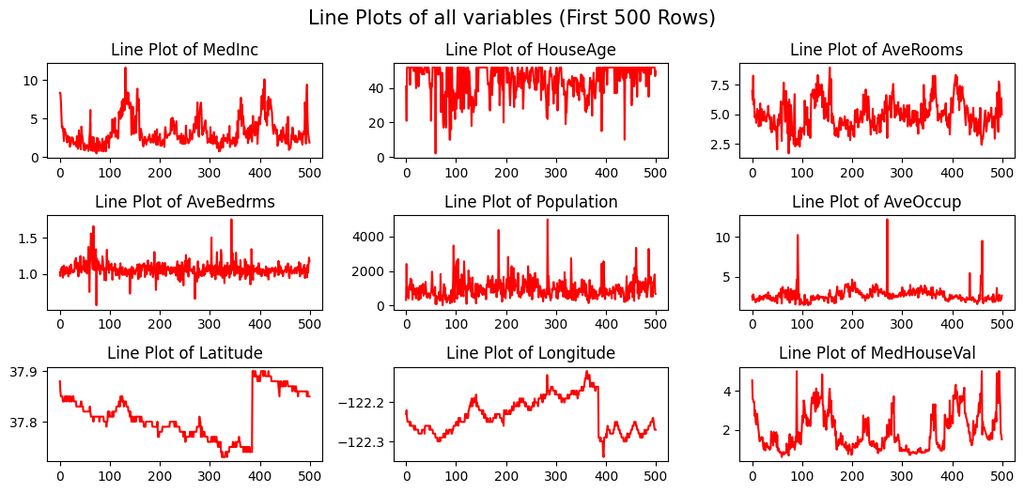

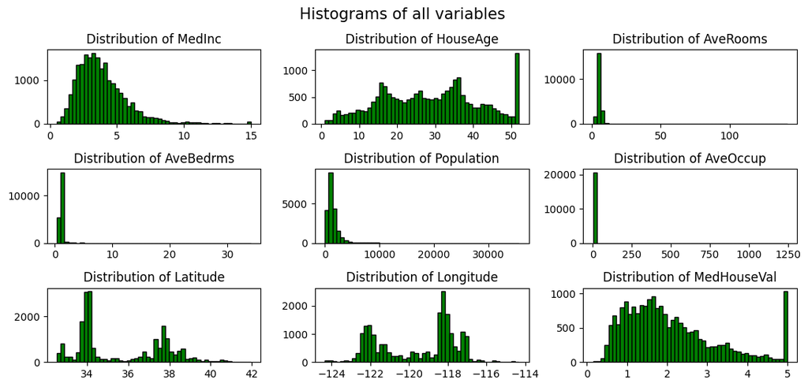

```python
# Set up the plotting grid for lineplots (quick value inspection)
plt.figure(figsize=(11, 5))
for i, col in enumerate(df.columns):
    plt.subplot(3, 3, i + 1)
    plt.plot(df[col].values[:500], color='red')  # plot first 500 values
    plt.title(f'Line Plot of {col}')
    plt.tight_layout()
plt.suptitle("Line Plots of all variables (First 500 Rows)", fontsize=15, y=1.04)
plt.show()

# Set up the plotting grid for histograms
plt.figure(figsize=(11, 5))
for i, col in enumerate(df.columns):
    plt.subplot(3, 3, i + 1)
    plt.hist(df[col], bins=50, color='green', edgecolor='black')
    plt.title(f'Distribution of {col}')
    plt.tight_layout()
plt.suptitle("Histograms of all variables", fontsize=15, y=1.04)
plt.show()
```

```python
# Outliers detection for selected features
## Our guess is that the outliers present in the features below may negatively affect the model

features = ['AveRooms', 'AveBedrms', 'AveOccup']
bounds = {
    feature: df[feature].quantile([0.01, 0.99]).values
    for feature in features
}

## Boolean masks for outliers per feature
outlier_masks = {
    feature: (df[feature] < bounds[feature][0]) | (df[feature] > bounds[feature][1])
    for feature in features
}

## Convert masks to DataFrame for easy counting
outlier_flags = pd.DataFrame(outlier_masks)

## Count of outlier rows per feature
print("Outliers per feature:")
print(outlier_flags.sum())

## Count how many rows are outliers in exactly 1, 2, or 3 features
outlier_flags['total_outlier_flags'] = outlier_flags.sum(axis=1)
multi_outlier_counts = outlier_flags['total_outlier_flags'].value_counts().sort_index()

print("\nNumber of rows that are outliers in:")
for i in range(1, len(features)+1):
    print(f"  {i} feature(s): {multi_outlier_counts.get(i, 0)} rows")

## Outlier-free df:
df_clean = df[outlier_flags['total_outlier_flags'] == 0].copy()

print("\n")
print("% change in standard deviation after removing outliers (per feature):\n")
std_change = 100 * ((df_clean.std() - df.std()) / df.std())
print(std_change.round(2))
```

```
Outliers per feature:
AveRooms     414
AveBedrms    414
AveOccup     414
dtype: int64

Number of rows that are outliers in:
  1 feature(s): 755 rows
  2 feature(s): 233 rows
  3 feature(s): 7 rows


% change in standard deviation after removing outliers (per feature):

MedInc         -1.12
HouseAge       -0.43
AveRooms      -52.00
AveBedrms     -76.09
Population     -3.22
AveOccup      -93.47
Latitude       -0.11
Longitude       0.03
MedHouseVal    -0.32
dtype: float64
```

```python
print("Change in linear correlation between feature and target variable after removing outliers:\n")
(abs(df_clean.corr()) - abs(df.corr())).loc['MedHouseVal'].round(4)
```

```
Change in linear correlation between feature and target variable after removing outliers:
```

```
MedInc         0.0186
HouseAge      -0.0015
AveRooms       0.2026
AveBedrms      0.0639
Population     0.0050
AveOccup       0.2668
Latitude       0.0060
Longitude     -0.0055
MedHouseVal    0.0000
Name: MedHouseVal, dtype: float64
```

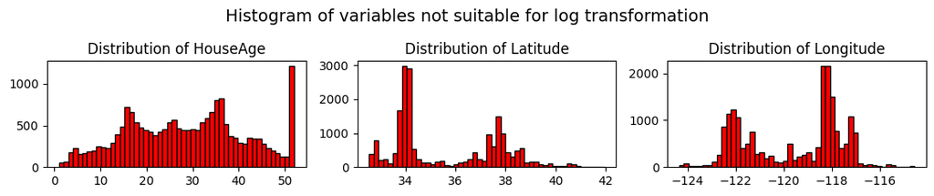

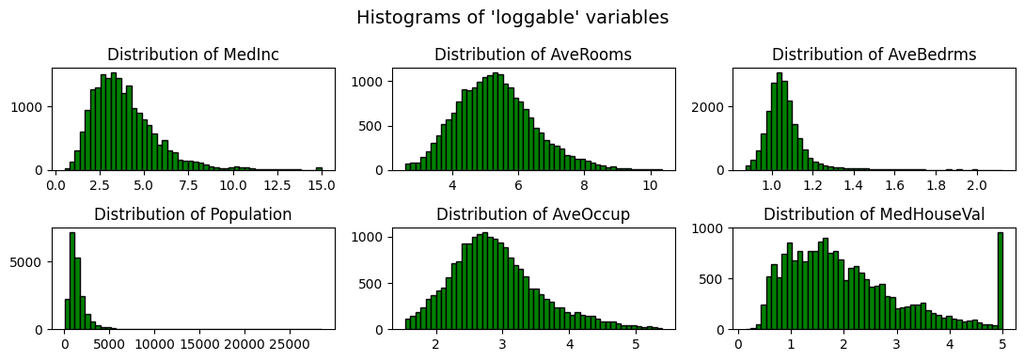

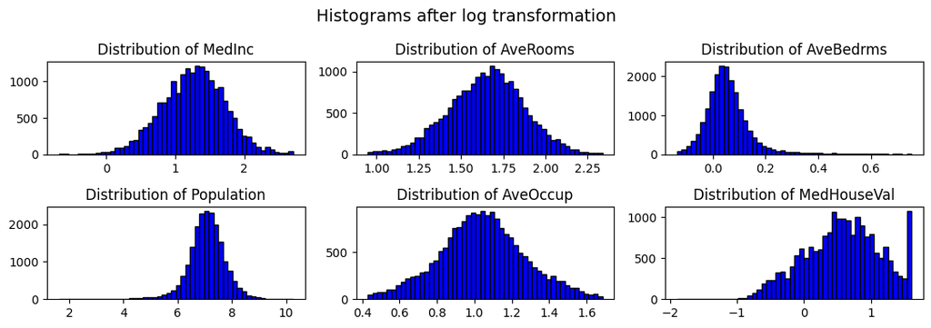

```python
# There are some variables far from being (log)normal - let's isolate them
## We will try to apply a log transformation to the other ones

plt.figure(figsize=(11, 2))
for i, col in enumerate(['HouseAge', 'Latitude', 'Longitude']):
    plt.subplot(1, 3, i + 1)
    plt.hist(df_clean[col], bins=50, color='red', edgecolor='black')
    plt.title(f'Distribution of {col}')
    plt.tight_layout()
plt.suptitle("Histogram of variables not suitable for log transformation", fontsize=14, y=1.12)
plt.show()

plt.figure(figsize=(11, 5))
for i, col in enumerate(df_clean.drop(columns=['HouseAge', 'Latitude', 'Longitude']).columns):
    plt.subplot(3, 3, i + 1)
    plt.hist(df_clean[col], bins=50, color='green', edgecolor='black')
    plt.title(f'Distribution of {col}')
    plt.tight_layout()
plt.suptitle("Histograms of 'loggable' variables", fontsize=14, y=1.05)
plt.show()

plt.figure(figsize=(11, 5))
for i, col in enumerate(df_clean.drop(columns=['HouseAge', 'Latitude', 'Longitude']).columns):
    plt.subplot(3, 3, i + 1)
    plt.hist(np.log(df_clean[col]), bins=50, color='blue', edgecolor='black')
    plt.title(f'Distribution of {col}')
    plt.tight_layout()
plt.suptitle("Histograms after log transformation", fontsize=14, y=1.05)
plt.show()
```

```python
# Identify log-transformed columns
log_transformed_cols = df_clean.columns.difference(['HouseAge', 'Latitude', 'Longitude', 'MedHouseVal'])
non_log_cols = ['HouseAge', 'Latitude', 'Longitude']

# Apply log transform to selected columns
df_log = np.log(df_clean[log_transformed_cols].copy())

# Join with the remaining columns
df_ult = df_log.join(df_clean[non_log_cols + ['MedHouseVal']])
```

# Linear regression

### First steps

```python
# Split into predictors and target variable
## We can overwrite X and y variables for our regression purposes
X = df_ult.drop(columns='MedHouseVal')
y_original = df_ult['MedHouseVal'] # Original scale
y = np.log(y_original) # Log scale - we will mainly use this

# Standardize manually and store the parameters
def standardize(df):
    mean = df.mean()
    std = df.std()
    scaled = (df - mean) / std
    return scaled, {'mean': mean, 'std': std}

# For later use
def inverse_standardize(scaled, params):
    return scaled * params['std'] - params['mean']

# Scale X; no need to scale y
X_scaled, scaling_params_X = standardize(X)
```

```python
# All the steps to make our prediction through a linear regression

## We need the parameters matrix + the intercept in front (a column of ones)
def predictors_matrix(X):
    X_b = np.c_[np.ones((X.shape[0], 1)), X] # Bias term + predictors
    return X_b

## We find the optimal coefficients through the "normal equation"
def normal_equation(X, y):
    X_b = predictors_matrix(X)
    beta = np.linalg.pinv(X_b.T @ X_b) @ X_b.T @ y # We use 'pinv' instead of 'inv' to avoid calculation issues in case of singular matrix
    return beta

## Ultimate goal: prediction
def predict(X, beta):
    X_b = predictors_matrix(X)
    y_hat = X_b @ beta # Multiply the predictors by their coefficient
    return y_hat
```

```python
# Fuction to evaluate the model with the most common metrics

def evaluate_model(
    y_true,
    y_pred,
    inputs: str,
    outputs: str = 'original',
    sigma2: float = 0,
    label: str = "Test Set"
) -> dict:
    """
    Evaluate regression model predictions where y is in log or original scale.
    Accepts either NumPy arrays or pandas Series for y values.
    """
    # Convert to numpy arrays for safety
    y_true = np.asarray(y_true)
    y_pred = np.asarray(y_pred)

    valid_spaces = {"log", "original"}
    if inputs not in valid_spaces or outputs not in valid_spaces:
        raise ValueError("`inputs` and `outputs` must be either 'log' or 'original'.")

    print(f"*** Model predicted in: {inputs} space.")
    print(f"*** Evaluating in:      {outputs} space.\n")

    # Transform values accordingly
    if inputs == "log" and outputs == "original":
        y_true = np.exp(y_true)
        y_pred = np.exp(y_pred + 0.5 * sigma2)
    elif inputs == "original" and outputs == "log":
        y_true = np.log(y_true)
        y_pred = np.log(y_pred) - 0.5 * sigma2

    # Compute metrics
    mse = np.mean((y_true - y_pred) ** 2)
    rmse = np.sqrt(mse)
    ss_res = np.sum((y_true - y_pred) ** 2)
    ss_tot = np.sum((y_true - np.mean(y_true)) ** 2)
    r2 = 1 - ss_res / ss_tot

    # Display results
    print(f"--- |Evaluation Results| — {label}")
    print("────────────────────────────────────")
    print(f"· MSE : {mse:,.4f}")
    print(f"· RMSE: {rmse:,.4f}")
    print(f"· R²  : {r2:.4f}")
    print("────────────────────────────────────\n")

    return {"MSE": mse, "RMSE": rmse, "R2": r2}
```

```python
# Set a random seed for reproducibility
np.random.seed(42)

# Shuffle the indices of the dataset
indices = np.random.permutation(len(X_scaled))

# Determine the train size (80% of the data)
train_size = int(0.8 * len(X_scaled))

# Split the indices into training and test sets
train_indices = indices[:train_size]
test_indices = indices[train_size:]

X_train, X_test = X_scaled.iloc[train_indices], X_scaled.iloc[test_indices]
y_train, y_test = y.iloc[train_indices], y.iloc[test_indices]

y_original_train, y_original_test = y_original.iloc[train_indices], y_original.iloc[test_indices]
```

## Run and evaluate

### Predicting

We begin by training the model to predict **log(y)**, which is our preferred target transformation. Subsequently, we train the model to predict **y** directly and compare the two approaches.

```python
# Train the model using the training set
beta = normal_equation(X_train.values, y_train.values)

# Predict on the test set
y_pred_test = predict(X_test.values, beta)

# Predict on the train set for comparison
y_pred_train = predict(X_train.values, beta)
```

```python
# If we want to evaluate the model in the original space,
# we must correct for the bias term introduced with the log transformation
# to do so, we need to compute the residual variance

def residual_variance_unbiased(y_true, y_pred, p):
    """
    Compute the unbiased estimator of residual variance.

    Args:
        y_true (np.ndarray): Actual target values.
        y_pred (np.ndarray): Predicted target values.
        p (int): Number of parameters used in the model (including intercept).

    Returns:
        float: Unbiased estimate of residual variance.
    """
    n = len(y_true)
    rss = np.sum((y_true - y_pred) ** 2)
    return rss / (n - p - 1)

p = X_train.shape[1]
sigma2 = residual_variance_unbiased(y_train.values, y_pred_train, p)
print(f"Unbiased residual variance estimate: {sigma2:.4f}")
```

```
Unbiased residual variance estimate: 0.0915
```

```python
print("Let's check the performance in the two different spaces (log and original)\n\n")

print("Log space:\n")

results_test = evaluate_model(y_test, y_pred_test, inputs='log', outputs='log', label="Test Set")
results_train = evaluate_model(y_train, y_pred_train, inputs='log', outputs='log', label="Train Set")

print("**"*25, "\n")

print("Original space:\n")

results_test = evaluate_model(y_test, y_pred_test, inputs='log', sigma2=sigma2, label="Test Set")
results_train = evaluate_model(y_train, y_pred_train, inputs='log', sigma2=sigma2, label="Train Set")
```

```
Let's check the performance in the two different spaces (log and original)


Log space:

*** Model predicted in: log space.
*** Evaluating in:      log space.

--- |Evaluation Results| — Test Set
────────────────────────────────────
· MSE : 0.1002
· RMSE: 0.3165
· R²  : 0.6936
────────────────────────────────────

*** Model predicted in: log space.
*** Evaluating in:      log space.

--- |Evaluation Results| — Train Set
────────────────────────────────────
· MSE : 0.0914
· RMSE: 0.3024
· R²  : 0.7149
────────────────────────────────────


Original space:

*** Model predicted in: log space.
*** Evaluating in:      original space.

--- |Evaluation Results| — Test Set
────────────────────────────────────
· MSE : 0.3978
· RMSE: 0.6307
· R²  : 0.7028
────────────────────────────────────

*** Model predicted in: log space.
*** Evaluating in:      original space.

--- |Evaluation Results| — Train Set
────────────────────────────────────
· MSE : 0.3788
· RMSE: 0.6155
· R²  : 0.7128
────────────────────────────────────
```

```python
# Let's observe whether the performance improves or worsens if we aim to predict directly y

beta_original = normal_equation(X_train.values, y_original_train.values)
y_original_pred_test = predict(X_test.values, beta_original)
y_original_pred_train = predict(X_train.values, beta_original)

results_test_original = evaluate_model(y_original_test, y_original_pred_test, inputs='original', label="Test Set")
results_train_original = evaluate_model(y_original_train, y_original_pred_train, inputs='original', label="Train Set")
```

```
*** Model predicted in: original space.
*** Evaluating in:      original space.

--- |Evaluation Results| — Test Set
────────────────────────────────────
· MSE : 0.4902
· RMSE: 0.7002
· R²  : 0.6339
────────────────────────────────────

*** Model predicted in: original space.
*** Evaluating in:      original space.

--- |Evaluation Results| — Train Set
────────────────────────────────────
· MSE : 0.4656
· RMSE: 0.6823
· R²  : 0.6471
────────────────────────────────────
```

### Comparing residuals

```python
residuals_log = y_pred_test - y_test
residuals = np.exp(y_pred_test + 0.5 * sigma2) - np.exp(y_test) # We could also use y_original_test, but for clarity we use this form
residuals_orig = y_original_pred_test - y_original_test
```

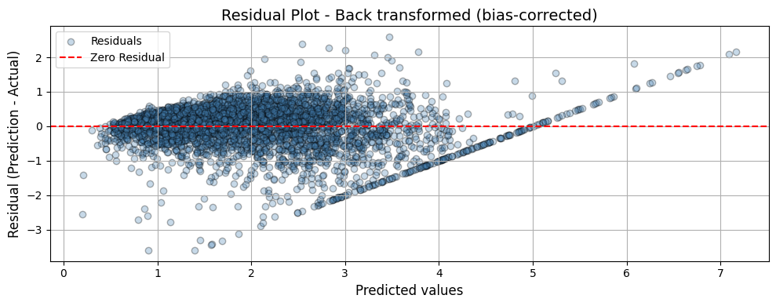

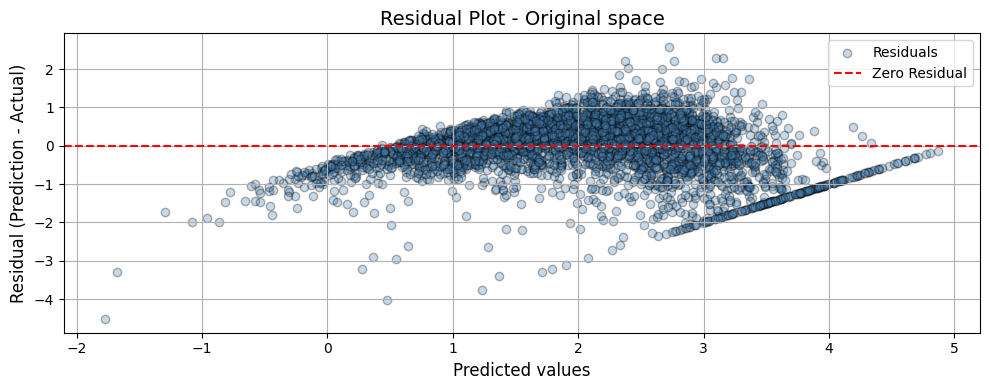

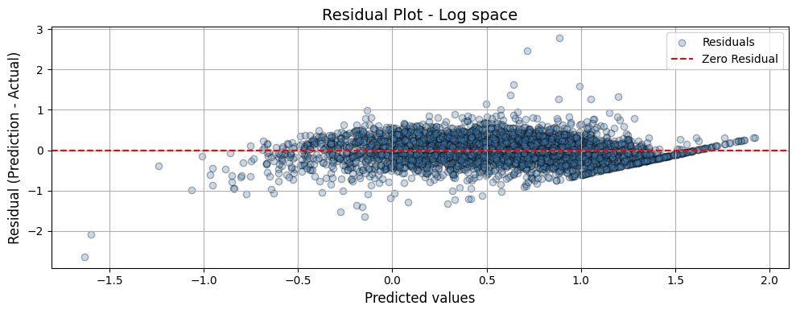

```python
def plot_residuals(residuals, y_pred, label=None):
    """
    Plot residuals between predicted and true values.
    """

    plt.figure(figsize=(10, 4))
    plt.scatter(y_pred, residuals, alpha=0.3, color='steelblue', edgecolor='k', label='Residuals')
    plt.axhline(y=0, color='red', linestyle='--', linewidth=1.5, label='Zero Residual')

    plt.xlabel(f"Predicted values", fontsize=12)
    plt.ylabel("Residual (Prediction - Actual)", fontsize=12)
    plt.title(f"Residual Plot - {label}", fontsize=14)
    plt.legend()
    plt.grid(True)
    plt.tight_layout()
    plt.show()

plot_residuals(residuals, np.exp(y_pred_test + 0.5*sigma2), label="Back transformed (bias-corrected)")
plot_residuals(residuals_orig, y_original_pred_test, label="Original space")
plot_residuals(residuals_log, y_pred_test, label="Log space")
```

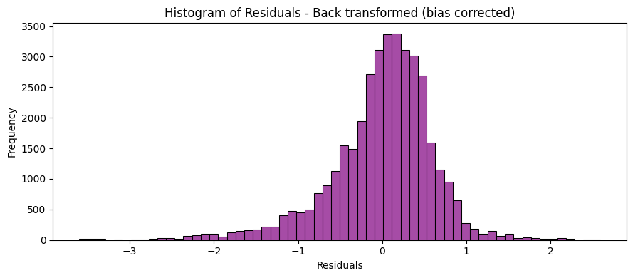

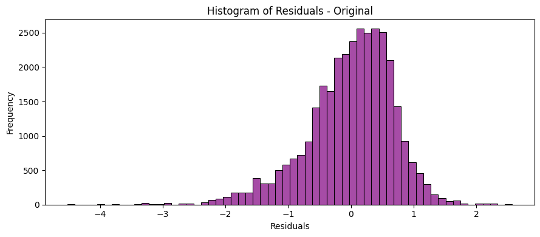

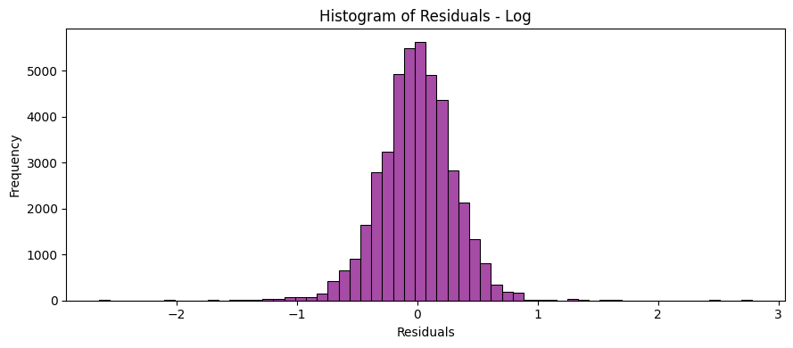

```python
def plot_residuals_histogram(residuals, label=None):
    """
    Plot histogram of residuals to check for normality.
    """
    plt.figure(figsize=(9, 4))
    sns.histplot(residuals, bins=60, color='purple', alpha=0.7, stat='frequency')
    plt.xlabel('Residuals')
    plt.title(f'Histogram of Residuals - {label}')
    plt.tight_layout()
    plt.show()

plot_residuals_histogram(residuals, label="Back transformed (bias corrected)")
plot_residuals_histogram(residuals_orig, label="Original")
plot_residuals_histogram(residuals_log, label="Log")
```

### Interpreting coefficients

```python
# Interpretation of the coefficients of our mixed log-log and log-lin regression
## Note that we are interpreting the coefficients of the better model - i.e. the one trained to predict log(y)

def interpret_coefficients(beta, feature_names, scaling_params_X, log_transformed_cols, p=1, decimals=3):
    """
    Interpret coefficients from a log-linear model using both:
    - 1 standard deviation increase (for variable importance),
    - p% or p-unit increase (for practical interpretability),
    distinguishing between log- and non-log-transformed features.
    """
    intercept = beta[0]
    coefs = beta[1:]

    print("\n|*** Coefficient Interpretation ***|")
    print("──────────────────────────────────────────────────────────────────────────")
    print(f"Intercept (log scale): {intercept:.{decimals}f}  →  exp(intercept) = {np.exp(intercept):,.{decimals}f}")
    print("──────────────────────────────────────────────────────────────────────────")

    for name, b in zip(feature_names, coefs):
        std = scaling_params_X['std'][name]
        unscaled_b = b / std

        print(f"\n--> {name}")
        print(f"  β (standardized): {b:+.{decimals}f}")
        print(f"  β (unscaled)    : {unscaled_b:+.{decimals}f}")

        if name in log_transformed_cols:
            # 1σ increase in log(X)
            sigma_pct_change = 100 * (1 - np.exp(-b))
            # +p% increase in X (original scale)
            a = np.log((100 + p) / 100)
            pct_change = 100 * (1 - np.exp(-a * unscaled_b))

            print(f"  → 1σ ↑ in log(X)       → {sigma_pct_change:+.{decimals-1}f}% change in price")
            print(f"  → +{p}% ↑ in X         → {pct_change:+.{decimals-1}f}% change in price")
        else:
            # 1σ increase in X
            sigma_pct_change = 100 * (np.exp(b) - 1)
            # +p unit increase in X
            pct_change = 100 * (np.exp(p * unscaled_b) - 1)

            print(f"  → 1σ ↑ in X            → {sigma_pct_change:+.{decimals-1}f}% change in price")
            print(f"  → +{p} unit ↑ in X     → {pct_change:+.{decimals-1}f}% change in price")

    print("──────────────────────────────────────────────────────────────────────────\n")

feature_names = X_scaled.columns
interpret_coefficients(beta, feature_names, scaling_params_X, log_transformed_cols)
```

```
|*** Coefficient Interpretation ***|
──────────────────────────────────────────────────────────────────────────
Intercept (log scale): 0.575  →  exp(intercept) = 1.776
──────────────────────────────────────────────────────────────────────────

--> AveBedrms
  β (standardized): +0.047
  β (unscaled)    : +0.503
  → 1σ ↑ in log(X)       → +4.62% change in price
  → +1% ↑ in X         → +0.50% change in price

--> AveOccup
  β (standardized): -0.123
  β (unscaled)    : -0.535
  → 1σ ↑ in log(X)       → -13.04% change in price
  → +1% ↑ in X         → -0.53% change in price

--> AveRooms
  β (standardized): -0.058
  β (unscaled)    : -0.261
  → 1σ ↑ in log(X)       → -6.02% change in price
  → +1% ↑ in X         → -0.26% change in price

--> MedInc
  β (standardized): +0.384
  β (unscaled)    : +0.833
  → 1σ ↑ in log(X)       → +31.90% change in price
  → +1% ↑ in X         → +0.83% change in price

--> Population
  β (standardized): +0.014
  β (unscaled)    : +0.020
  → 1σ ↑ in log(X)       → +1.37% change in price
  → +1% ↑ in X         → +0.02% change in price

--> HouseAge
  β (standardized): +0.046
  β (unscaled)    : +0.004
  → 1σ ↑ in X            → +4.68% change in price
  → +1 unit ↑ in X     → +0.37% change in price

--> Latitude
  β (standardized): -0.567
  β (unscaled)    : -0.266
  → 1σ ↑ in X            → -43.29% change in price
  → +1 unit ↑ in X     → -23.35% change in price

--> Longitude
  β (standardized): -0.513
  β (unscaled)    : -0.256
  → 1σ ↑ in X            → -40.14% change in price
  → +1 unit ↑ in X     → -22.59% change in price
──────────────────────────────────────────────────────────────────────────
```

## Making predictions from inputs

- We need inputs (in original or log scale, depending on our model)
- We standardize inputs
- We use the beta (coefficients) obtained in the training phase to get log(y)
- We exponentiate log(y) and remove the bias through the variance correction to get the predicted value of y

```python
# Recall what are the predictors
X.head(3)
```

|  | AveBedrms | AveOccup | AveRooms | MedInc | Population | HouseAge | Latitude | Longitude |
| --- | --- | --- | --- | --- | --- | --- | --- | --- |
| 0 | 0.023530 | 0.938270 | 1.943640 | 2.119287 | 5.774552 | 41.0 | 37.88 | -122.23 |
| 1 | -0.028522 | 0.746613 | 1.830682 | 2.116424 | 7.783641 | 21.0 | 37.86 | -122.22 |
| 2 | 0.070874 | 1.030426 | 2.114825 | 1.982022 | 6.206576 | 52.0 | 37.85 | -122.24 |

```python
# We use the best model - the one that predicts log(y)

def make_forecast(input_values):
    """
    input_values (dict): dictionary of input features
    Returns: predicted MedHouseVal in original scale
    """

    # Apply log transform where needed
    processed_inputs = { key: np.log(value) if key in log_transformed_cols else value
                        for key, value in input_values.items() }
    # Standardize
    scaled_values = { key: (value - scaling_params_X['mean'][key]) / scaling_params_X['std'][key] for key, value in processed_inputs.items() }

    # Add the intercept and multiply by the coefficients
    X_vector = np.concatenate((
        [1],
        np.array(list(scaled_values.values()))
                              ))
    prediction = X_vector @ beta

    # Transform back
    y_hat = np.exp(prediction + 0.5 * sigma2) # Recall the variance correction

    # Result
    return y_hat
```

```python
# Insert input values in the correct order
## FIrst insert log transformed variables, then the ones left
### The values are arbitrarily chosen

input_values = {
    'AveBedrms': 1.2,
    'AveOccup': 2.1,
    'AveRooms': 7,
    'MedInc': 7.5,
    'Population': 1500,
    'HouseAge': 30,
    'Latitude': 37.81,
    'Longitude': -122.26
               }

forecast = make_forecast(input_values)

print(f"The predicted median house value is: \n$ {100_000 * forecast:,.2f}")
```

```
The predicted median house value is:
$ 454,039.54
```

```python
### Done!
```